# Health Data Science

# 1 Introduction

Problem Statement The objective of this study is to investigate the negative health effects associated with smoking, including both physical and mental health outcomes. Given the widespread prevalence of smoking and the rising use of electronic nicotine products, it is crucial to understand the extent to which these habits impact overall health. Our analysis will focus on identifying the associations between smoking and various health-related issues, as well as exploring the relationship between smoking habits and mental health indicators. Additionally, we will compare these findings with the health effects associated with the use of electronic nicotine products.

The central question we want to answer is: what are the negative health effects associated with smoking? We will look at the association between smoking and health related issues. We will also look at some mental health indicators and how they relate to smoking habits. We will also make an interesting comparison with usage of electronic nicotine products.

Abstract The negative health effects of smoking have been well-documented, yet the comprehensive impact on both physical and mental health continues to be a critical area of study. This research aims to analyze the associations between smoking and health-related issues using data from the 2021 Medical Expenditure Panel Survey Household Component, which surveyed 15,000 households in the United States. By examining physical health outcomes and mental health indicators, this study seeks to provide a detailed understanding of how smoking affects individuals. Furthermore, we will compare these effects with those associated with the use of electronic nicotine products, offering insights into the potential risks of these increasingly popular alternatives. Our findings aim to inform public health strategies and contribute to ongoing efforts to mitigate the health risks associated with smoking and electronic nicotine product usage.

The dataset we are working with is the Medical Expenditure Panel Survey Household component of 2021. It’s a survey conducted on 15000 households in the United States of America.

*Here is info about characteristics:* https://meps.ahrq.gov/data_files/publications/st554/stat554.shtml

*Here is questionary report:* https://meps.ahrq.gov/survey_comp/hc_survey/paper_quest/2021/2021_SHE_SAQ.pdf

*Codebook:* https://meps.ahrq.gov/data_stats/download_data/pufs/h233/h233cb.pdf

```r
# the dataset is in the github repo, we don't need to download it every time
h233 <- read_dta("h233.dta")
head(h233)
```

```
## # A tibble: 6 × 1,488
##      DUID   PID DUPERSID   PANEL         FAMID31 FAMID42 FAMID53 FAMID21 FAMIDYR
##     <dbl> <dbl> <chr>      <dbl+lbl>     <chr>   <chr>   <chr>   <chr>   <chr>
## 1 2320005   101 2320005101 23 [23 PANEL… A       A       A       A       A
## 2 2320005   102 2320005102 23 [23 PANEL… A       A       A       A       A
## 3 2320006   101 2320006101 23 [23 PANEL… A       A       A       A       A
## 4 2320006   102 2320006102 23 [23 PANEL… B       B       B       B       B
## 5 2320006   103 2320006103 23 [23 PANEL… A       A       A       A       A
## 6 2320012   102 2320012102 23 [23 PANEL… A       A       A       A       A
## # ℹ 1,479 more variables: CPSFAMID <chr>, FCSZ1231 <dbl+lbl>,
## #   FCRP1231 <dbl+lbl>, RULETR31 <chr>, RULETR42 <chr>, RULETR53 <chr>,
## #   RULETR21 <chr>, RUSIZE31 <dbl+lbl>, RUSIZE42 <dbl+lbl>, RUSIZE53 <dbl+lbl>,
## #   RUSIZE21 <dbl+lbl>, RUCLAS31 <dbl+lbl>, RUCLAS42 <dbl+lbl>,
## #   RUCLAS53 <dbl+lbl>, RUCLAS21 <dbl+lbl>, FAMSZE31 <dbl+lbl>,
## #   FAMSZE42 <dbl+lbl>, FAMSZE53 <dbl+lbl>, FAMSZE21 <dbl+lbl>,
## #   FMRS1231 <dbl+lbl>, FAMS1231 <dbl+lbl>, FAMSZEYR <dbl+lbl>, …
```

Our main explanatory variables:

ADSMOK42: currently smokes

SDENICPROD: used electronic nicotine product

The other variables we selected are:

ADNSMK42 - If ADSMOK42 = 1, doctor advised you to quit smoking

Other variables we selected can be grouped as follows:

Demographic variables: AGELAST, REGION21, SEX, RACEV2X, MARRY21X, FTSTU21X, TTLP21X, FAMINC21, EMPST31

Mental health: ADDPRS42, ADHOPE42, ADNERV42, ADPCFL42, ADSAD42, MNHLTH31

General health: ADGENH42, ADENGY42, RTHLTH31, WLKLIM53

Disease Diagnosis: ASTHDX, ARTHDX, CALUNG, CHOLDX, CHBRON31, DIABDX_M18, EMPHDX, HIBPDX, STRKDX

```r
vars_to_keep = c("ADSMOK42","SDENICPROD","ADDPRS42","ADGENH42",
                 "ADENGY42","ADHOPE42","ADNERV42","ADPCFL42","ADSAD42",
                 "AGELAST","ASTHDX","CALUNG","CHOLDX","DIABDX_M18","EMPHDX",
                 "FAMINC21","HIBPDX","MNHLTH31","RTHLTH31","TTLP21X",
                 "WLKLIM53","SDCOMPAN","SDLEFTOUT","SDLIFE", 'REGION21', 'RACEV2X',
                 'FTSTU21X', 'SEX','STRKDX','HIBPDX', 'MARRY21X','CHBRON31' ,'CANCERDX',
                 'ARTHDX', 'ADNSMK42', 'SDHOME', 'SDMEDCARE','SDHLTHFOOD', 'SDISOL',
                 'SDHMDEPR','SDHMALC','SDHMDRG', 'SDHMDIV', 'SDHMBEAT', 'SDHURTCHLD', 'EMPST31')

small_df = h233 %>% select(all_of(vars_to_keep)) %>% as_factor()
#turning the variables into factors

small_df = small_df %>% mutate(age_group = cut(AGELAST,
                                    breaks = c(-Inf,18, 25, 35, 45, 65, Inf),
                  labels = c("0-18","18-24", "25-34", "35-44", "45-64", "65+"),
                  right = FALSE))
#adding a new variable to break into age groups

small_df %>% summary()
```

```
##                    ADSMOK42                      SDENICPROD
##  -15 CANNOT BE COMPUTED:    0   -15 CANNOT BE COMPUTED:  216
##  -8 DK                 :    0   -1 INAPPLICABLE       : 9936
##  -7 REFUSED            :    0   1 YES                 : 2419
##  -1 INAPPLICABLE       :12914   2 NO                  :15765
##  1 YES                 : 2831
##  2 NO                  :12591
##
##                       ADDPRS42                       ADGENH42
##  -15 CANNOT BE COMPUTED   :  225   -15 CANNOT BE COMPUTED:  482
##  -1 INAPPLICABLE          :12914   -1 INAPPLICABLE       :12914
##  0 NOT AT ALL             :11473   1 EXCELLENT           : 2461
##  1 SEVERAL DAYS           : 2673   2 VERY GOOD           : 5284
##  2 MORE THAN HALF THE DAYS:  665   3 GOOD                : 4888
##  3 NEARLY EVERY DAY       :  386   4 FAIR                : 1953
##                                    5 POOR                :  354
##                      ADENGY42                       ADHOPE42
##  -1 INAPPLICABLE         :12914   -15 CANNOT BE COMPUTED:  228
##  2 MOST OF THE TIME      : 5565   -1 INAPPLICABLE       :12914
##  3 A GOOD BIT OF THE TIME: 2923   0 NONE OF THE TIME    :11623
##  4 SOME OF THE TIME      : 2634   1 LITTLE OF THE TIME  : 2009
##  1 ALL OF THE TIME       : 1744   2 SOME OF THE TIME    : 1033
##  5 LITTLE OF THE TIME    : 1361   3 MOST OF THE TIME    :  381
##  (Other)                 : 1195   4 ALL OF THE TIME     :  148
##                    ADNERV42                         ADPCFL42
##  -15 CANNOT BE COMPUTED:  187   -1 INAPPLICABLE         :12914
##  -1 INAPPLICABLE       :12914   2 MOST OF THE TIME      : 6314
##  0 NONE OF THE TIME    : 7832   1 ALL OF THE TIME       : 2639
##  1 LITTLE OF THE TIME  : 4507   3 A GOOD BIT OF THE TIME: 2636
##  2 SOME OF THE TIME    : 2107   4 SOME OF THE TIME      : 2061
##  3 MOST OF THE TIME    :  605   5 LITTLE OF THE TIME    :  885
##  4 ALL OF THE TIME     :  184   (Other)                 :  887
##                    ADSAD42         AGELAST                        ASTHDX
##  -15 CANNOT BE COMPUTED:  219   Min.   : 0.0   -15 CANNOT BE COMPUTED:   94
##  -1 INAPPLICABLE       :12914   1st Qu.:23.0   -8 DK                 :   20
##  0 NONE OF THE TIME    :12089   Median :44.0   -7 REFUSED            :   23
##  1 LITTLE OF THE TIME  : 1837   Mean   :43.2   -1 INAPPLICABLE       :   31
##  2 SOME OF THE TIME    :  855   3rd Qu.:64.0   1 YES                 : 4022
##  3 MOST OF THE TIME    :  299   Max.   :85.0   2 NO                  :24146
##  4 ALL OF THE TIME     :  123
```

[output cut: 113 more lines]

```
##  -15 CANNOT BE COMPUTED  :  246   1 EMPLOYED AT RD 3/1 INT DATE        :11989
##  -1 INAPPLICABLE         : 9936   4 NOT EMPLOYED DURING RD 3/1         :10186
##  1 NEVER                 :14042   -1 INAPPLICABLE                      : 5456
##  2 ONCE                  : 1415   3 JOB DURING RD 3/1 REF PERIOD       :  267
##  3 MORE THAN ONCE        : 2695   -7 REFUSED                           :  159
##  4 NEVER OR ONCE         :    2   2 JOB TO RETURN TO AT RD 3/1 INT DATE:  132
##  5 ONCE OR MORE THAN ONCE:    0   (Other)                              :  147
##  age_group
##  0-18 :5557
##  18-24:1988
##  25-34:3306
##  35-44:3479
##  45-64:7299
##  65+  :6707
##
```

# 2 Descriptive statistics

## 2.1 Demographic characteristics

We start by looking at the age distribution of people that took the survey

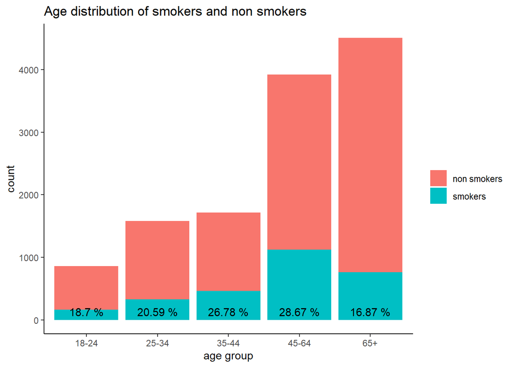

```r
#smokers by age group
small_df %>% select(ADSMOK42, age_group) %>% group_by(age_group) %>%
  summarise(n_smokers = sum(ADSMOK42 == "1 YES"),
            n_non_smokers = sum(ADSMOK42 == "2 NO"),
            n_inapplicable = sum(ADSMOK42 == "-1 INAPPLICABLE")) %>%
  mutate(perc_smokers = 100*n_smokers/n_non_smokers) %>%
  slice(-1) %>%
  ggplot(aes(x = age_group)) +
  geom_col(aes(y = n_non_smokers, fill = "non smokers")) +
  geom_col(aes(y = n_smokers, fill = "smokers")) +
  geom_text(aes(label=paste(round(perc_smokers,2),"%"), y = 130)) +
  labs(title = "Age distribution of smokers and non smokers",
       y = "count", x = "age group", fill = "") + theme_classic()
```

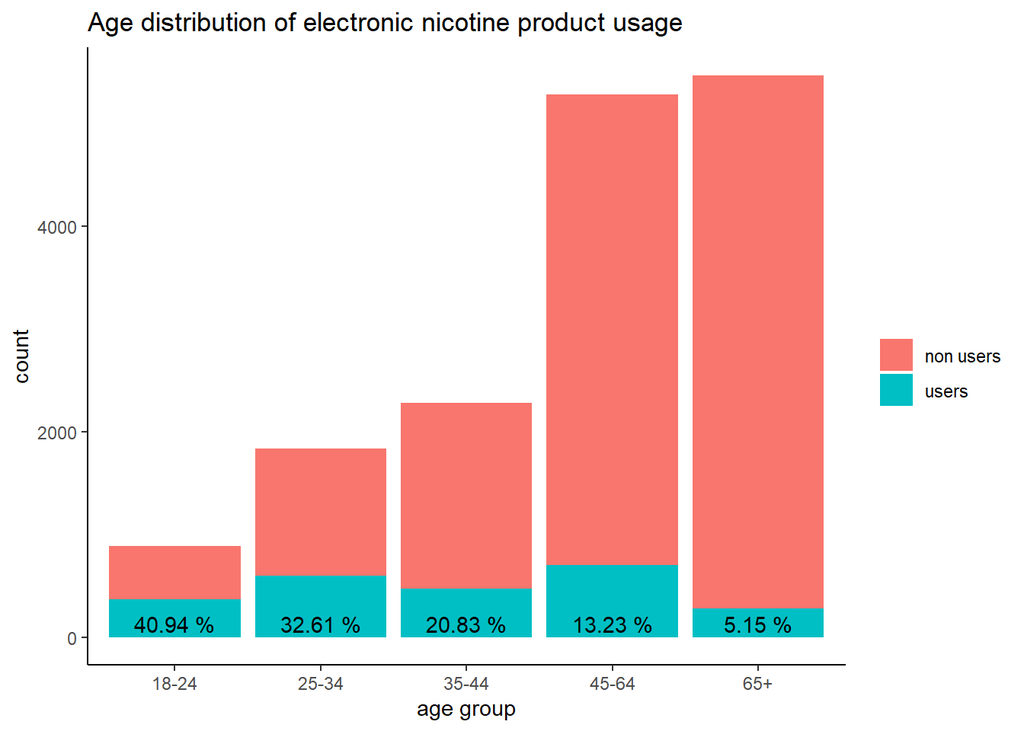

```r
# age distribution of users of electronic cigarettes
small_df %>% select(SDENICPROD, age_group) %>% group_by(age_group) %>%
  summarise(n_smokers = sum(SDENICPROD == "1 YES"),
            n_non_smokers = sum(SDENICPROD == "2 NO"),
            n_inapplicable = sum(SDENICPROD == "-1 INAPPLICABLE")) %>%
  mutate(perc_smokers = 100*n_smokers/n_non_smokers) %>%
  slice(-1) %>%
  ggplot(aes(x = age_group)) +
  geom_col(aes(y = n_non_smokers, fill = "non users")) +
  geom_col(aes(y = n_smokers, fill = "users")) +
  geom_text(aes(label=paste(round(perc_smokers,2),"%"), y = 130)) +
  labs(title = "Age distribution of electronic nicotine product usage",
       y = "count", x = "age group", fill = "") + theme_classic()
```

Smoking rate increases with age, till the 45-64 age group. They are the most likely to smoke. However the last age group, 65 and over is the one with the lowest rate. This fact is key to understand the effect of age: as is well known, general health decreases sharply with old age, so it will be important in our analysis to always control for the confounding effect of age.

Looking at electronic nicotine usage, we see a very different picture: in the youngest group there is a really high rate, 41%. Almost one every two young adults uses those products. The rate is decreasing with age: every older generation show a large decrease from the younger one. The 65+ group, which as we have already said is the one with the worst health, sees almost no usage: just over 5%.

The two variables will allow us to make interesting comparisons since the makeup of the groups is very different.

```r
small_df <- small_df %>%
  mutate(
    sex_group = case_when(
      SEX == '1 MALE' ~ 'MALE',
      SEX == '2 FEMALE' ~ 'FEMALE',
      TRUE ~ NA_character_
    )
  )
smokers_df <- small_df %>% filter(ADSMOK42 == "1 YES")

non_smokers_df <- small_df %>% filter(ADSMOK42 == "2 NO")

e_smokers_df <-small_df %>% filter(SDENICPROD == "1 YES")
```

### 2.1.1 Difference between smokers and non-smokers

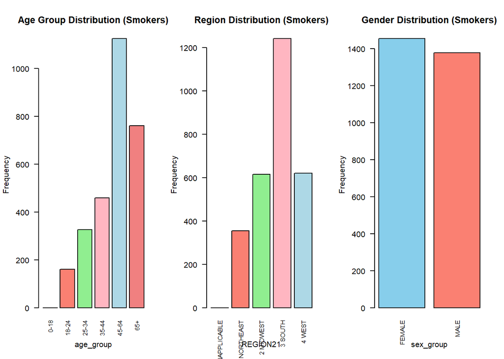

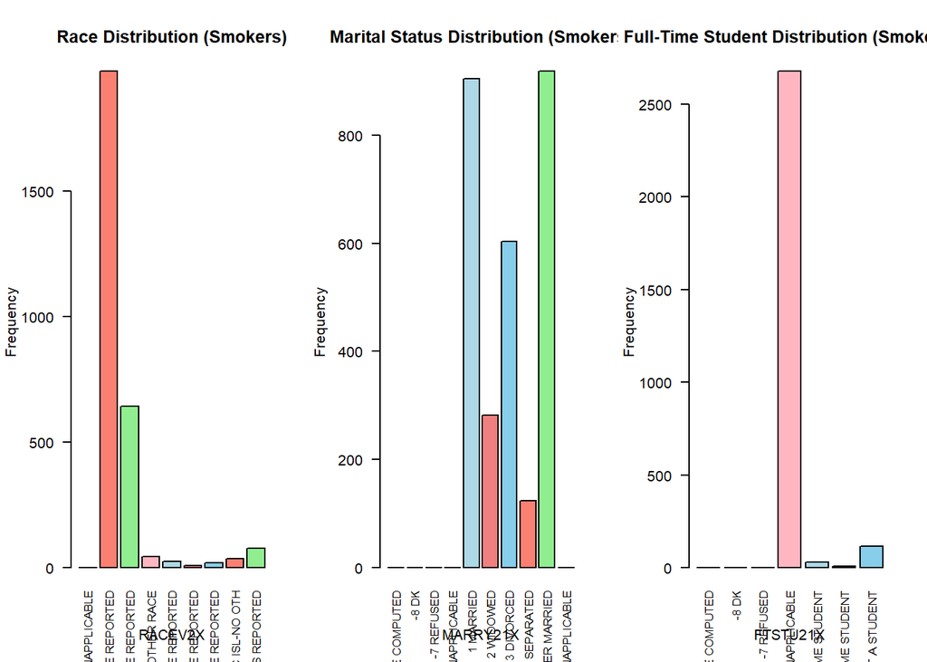

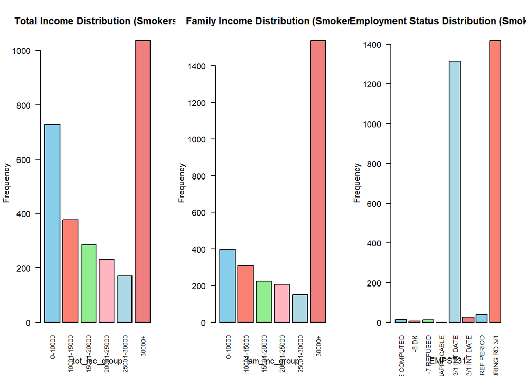

```r
create_plots_demogr <- function(data, demographic_variables, titles) {
  data <- data %>%
    mutate(
      tot_inc_group = cut(TTLP21X,
                          breaks = c(-Inf, 10000, 15000, 20000, 25000, 30000, Inf),
                          labels = c("0-10000", "10001-15000", "15001-20000", "20001-25000", "25001-30000", "30000+"),
                          right = FALSE),
      fam_inc_group = cut(FAMINC21,
                          breaks = c(-Inf, 10000, 15000, 20000, 25000, 30000, Inf),
                          labels = c("0-10000", "10001-15000", "15001-20000", "20001-25000", "25001-30000", "30000+"),
                          right = FALSE)
    ) %>%
    filter(!is.na(tot_inc_group) & !is.na(fam_inc_group) & !is.na(sex_group)) %>%
    filter(tot_inc_group != "NA")

  create_plots <- function(data, variable, title) {
    my_colors <- c("skyblue", "salmon", "lightgreen", "lightpink", "lightblue", "lightcoral")
    barplot(table(data[[variable]]), main = title, xlab = variable, ylab = "Frequency", las = 2, cex.names = 0.8, col = my_colors)
  }

  par(mfrow = c(1, 3))
  for (variable in demographic_variables) {
    create_plots(data, variable, titles[[variable]])
  }
}

demographic_variables <- c("age_group", "REGION21", "sex_group", "RACEV2X", "MARRY21X", "FTSTU21X", "tot_inc_group", "fam_inc_group", "EMPST31")

titles_smokers <- c(
  age_group = "Age Group Distribution (Smokers)",
  REGION21 = "Region Distribution (Smokers)",
  sex_group = "Gender Distribution (Smokers)",
  RACEV2X = "Race Distribution (Smokers)",
  MARRY21X = "Marital Status Distribution (Smokers)",
  FTSTU21X = "Full-Time Student Distribution (Smokers)",
  tot_inc_group = "Total Income Distribution (Smokers)",
  fam_inc_group = "Family Income Distribution (Smokers)",
  EMPST31 = "Employment Status Distribution (Smokers)"
)

titles_non_smokers <- c(
  age_group = "Age Group Distribution (Non-Smokers)",
  REGION21 = "Region Distribution (Non-Smokers)",
  sex_group = "Gender Distribution (Non-Smokers)",
  RACEV2X = "Race Distribution (Non-Smokers)",
  MARRY21X = "Marital Status Distribution (Non-Smokers)",
  FTSTU21X = "Full-Time Student Distribution (Non-Smokers)",
  tot_inc_group = "Total Income Distribution (Non-Smokers)",
  fam_inc_group = "Family Income Distribution (Non-Smokers)",
  EMPST31 = "Employment Status Distribution (Non-Smokers)"
)


create_plots_demogr(smokers_df, demographic_variables, titles_smokers)
```

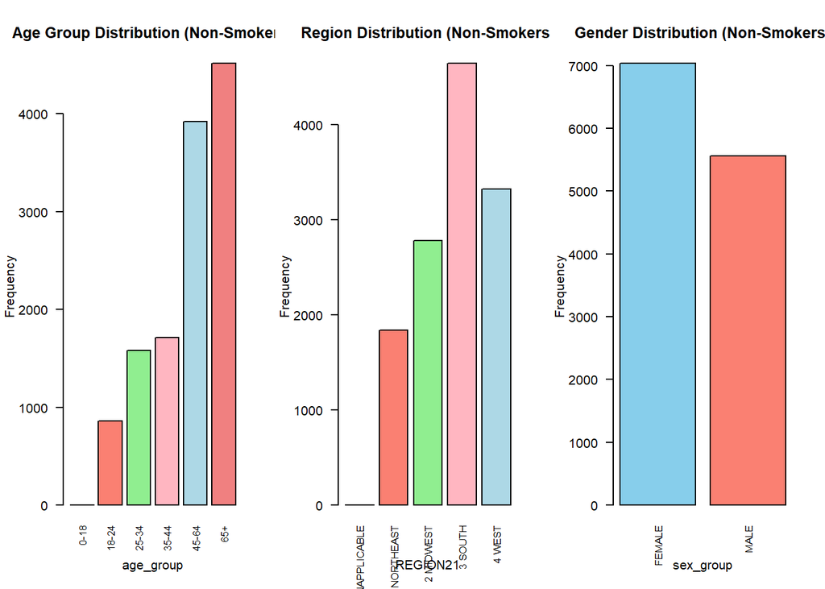

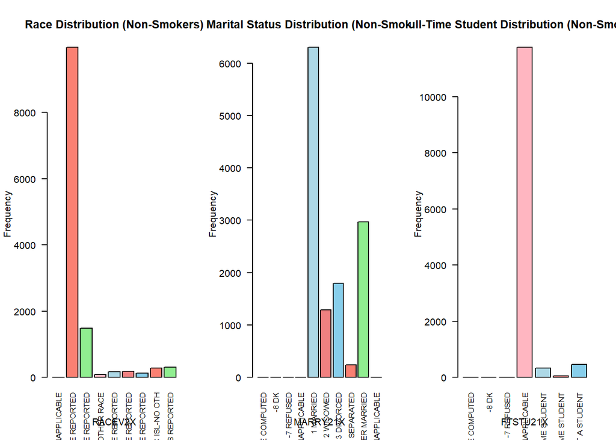

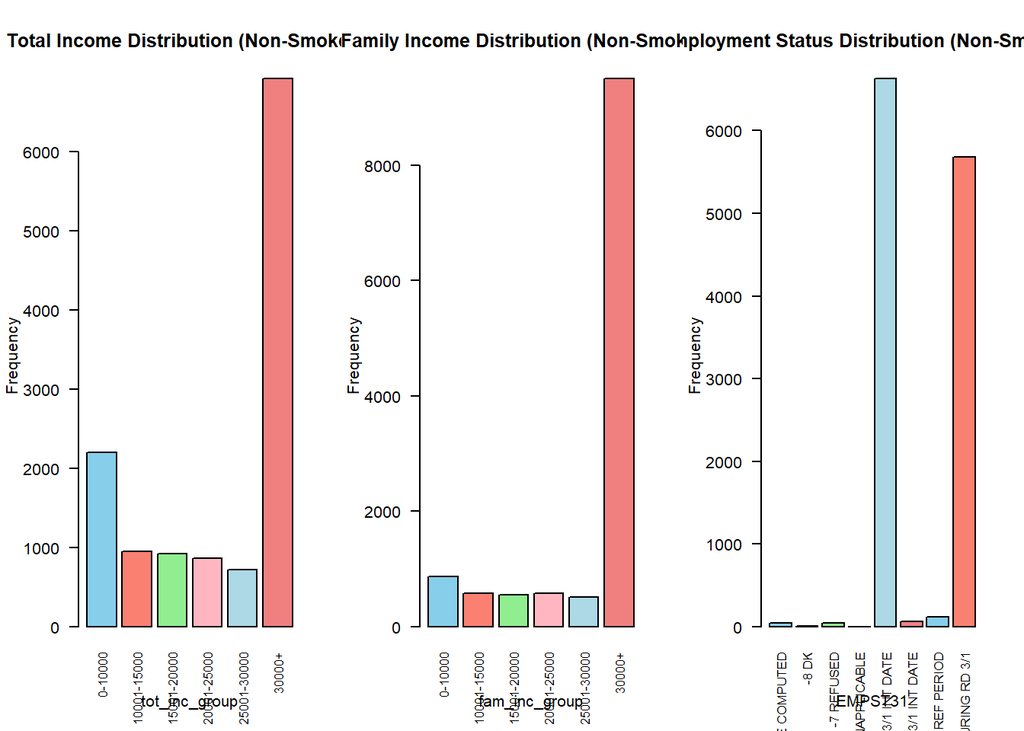

```r
create_plots_demogr(non_smokers_df, demographic_variables, titles_non_smokers)
```

Did smokers receive a doctor’s recommendation to quit?

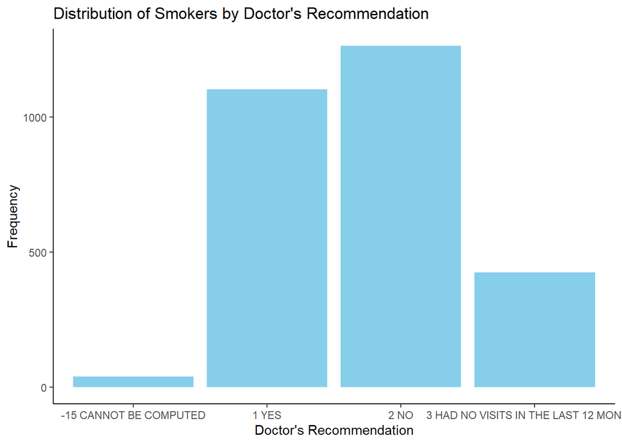

```r
ggplot(smokers_df, aes(x = ADNSMK42)) +
  geom_bar(fill = "skyblue") +
  labs(title = "Distribution of Smokers by Doctor's Recommendation", x = "Doctor's Recommendation", y = "Frequency") + theme_classic()
```

*38% of current smokers still smokes after doctor’s advice to quit smoke*

Smokers that also make use of electronic nicotine products

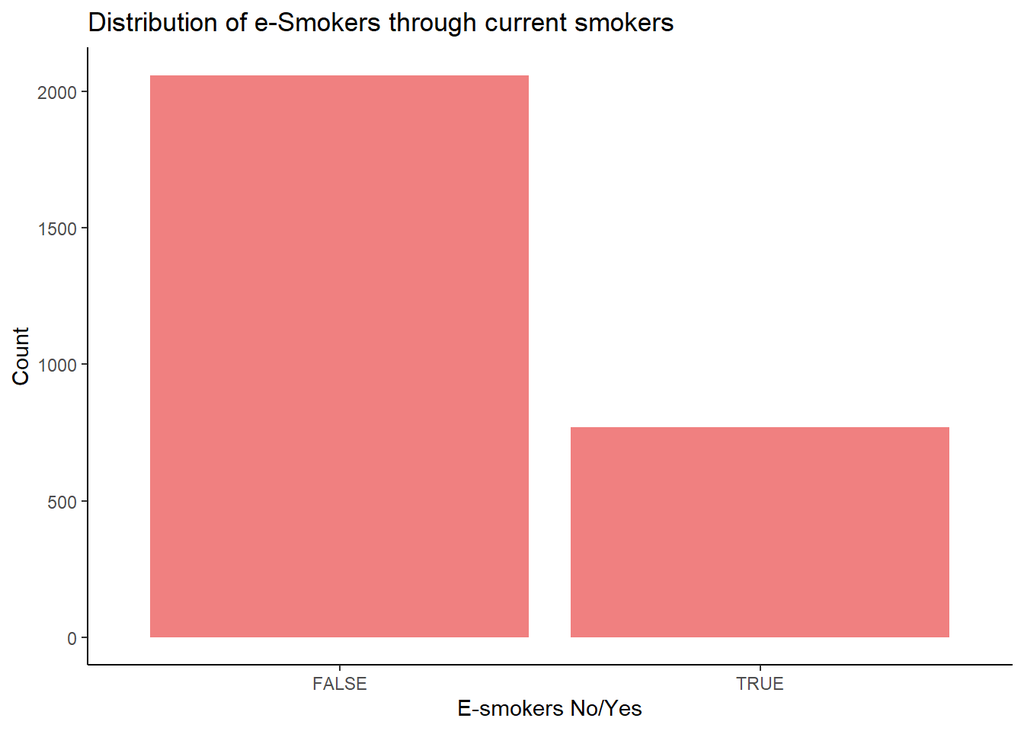

```r
ggplot(smokers_df, aes(x = SDENICPROD == "1 YES")) +
  geom_bar(fill = "lightcoral") +
  labs(title = "Distribution of e-Smokers through current smokers", x = "E-smokers No/Yes", y = "Count") + theme_classic()
```

This is the main reason why we looked at the two explanatory variables separately: the group that uses both is really small with only 700 people in a sample of 28,000 people

## 2.2 Mental Health Variables

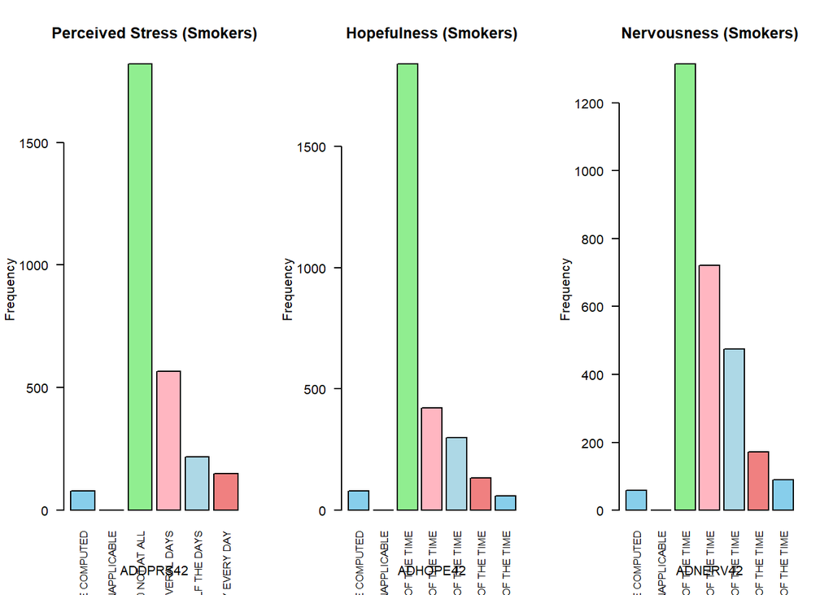

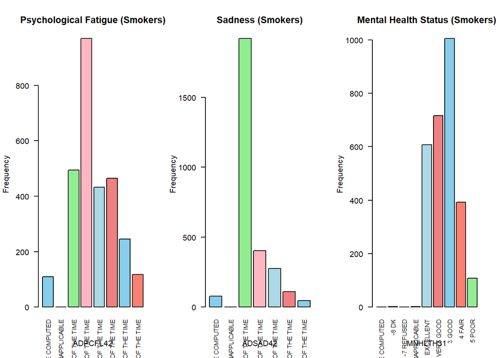

```r
#mental health
create_plots_mental_health <- function(data, mental_health_variables, titles) {
  data <- data %>%
    filter(!is.na(sex_group))

 create_plots <- function(data, variable, title) {
    my_colors <- c("skyblue", "salmon", "lightgreen", "lightpink", "lightblue", "lightcoral")
    barplot(table(data[[variable]]), main = title, xlab = variable, ylab = "Frequency", las = 2, cex.names = 0.8, col = my_colors)
  }

  par(mfrow = c(1, 3))
  for (variable in mental_health_variables) {
    create_plots(data, variable, titles[[variable]])
  }
}

mental_health_variables <- c("ADDPRS42", "ADHOPE42", "ADNERV42", "ADPCFL42", "ADSAD42", "MNHLTH31")


titles_smokers_mental_health <- c(
  ADDPRS42 = "Perceived Stress (Smokers)",
  ADHOPE42 = "Hopefulness (Smokers)",
  ADNERV42 = "Nervousness (Smokers)",
  ADPCFL42 = "Psychological Fatigue (Smokers)",
  ADSAD42 = "Sadness (Smokers)",
  MNHLTH31 = "Mental Health Status (Smokers)"
)

titles_non_smokers_mental_health <- c(
  ADDPRS42 = "Perceived Stress (Non-Smokers)",
  ADHOPE42 = "Hopefulness (Non-Smokers)",
  ADNERV42 = "Nervousness (Non-Smokers)",
  ADPCFL42 = "Psychological Fatigue (Non-Smokers)",
  ADSAD42 = "Sadness (Non-Smokers)",
  MNHLTH31 = "Mental Health Status (Non-Smokers)"
)

titles_e_smokers_mental_health <- c(
  ADDPRS42 = "Perceived Stress (E-Smokers)",
  ADHOPE42 = "Hopefulness (E-Smokers)",
  ADNERV42 = "Nervousness (E-Smokers)",
  ADPCFL42 = "Psychological Fatigue (E-Smokers)",
  ADSAD42 = "Sadness (E-Smokers)",
  MNHLTH31 = "Mental Health Status (E-Smokers)"
)
create_plots_mental_health(smokers_df, mental_health_variables, titles_smokers_mental_health)
```

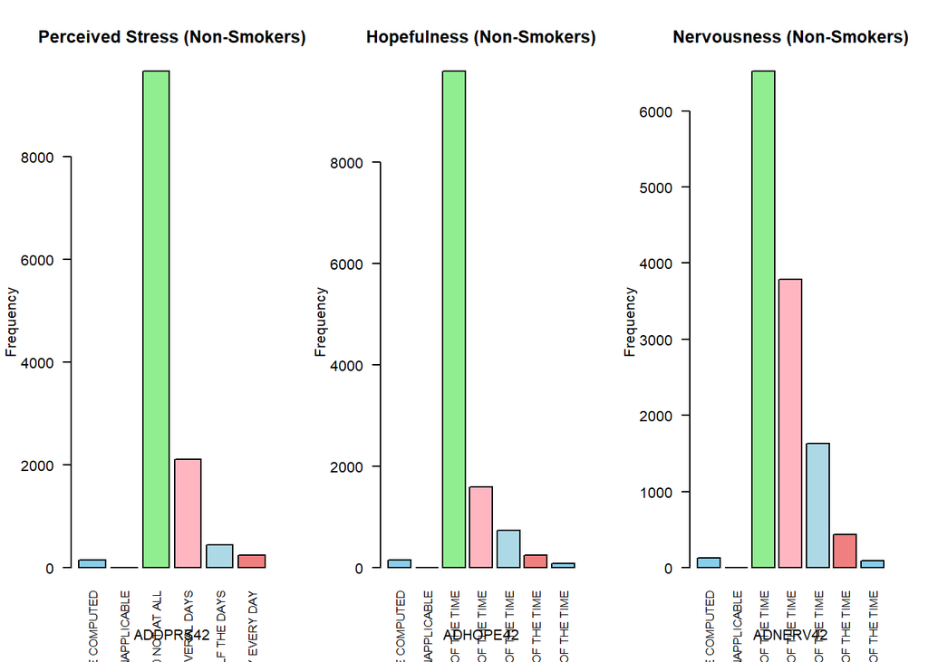

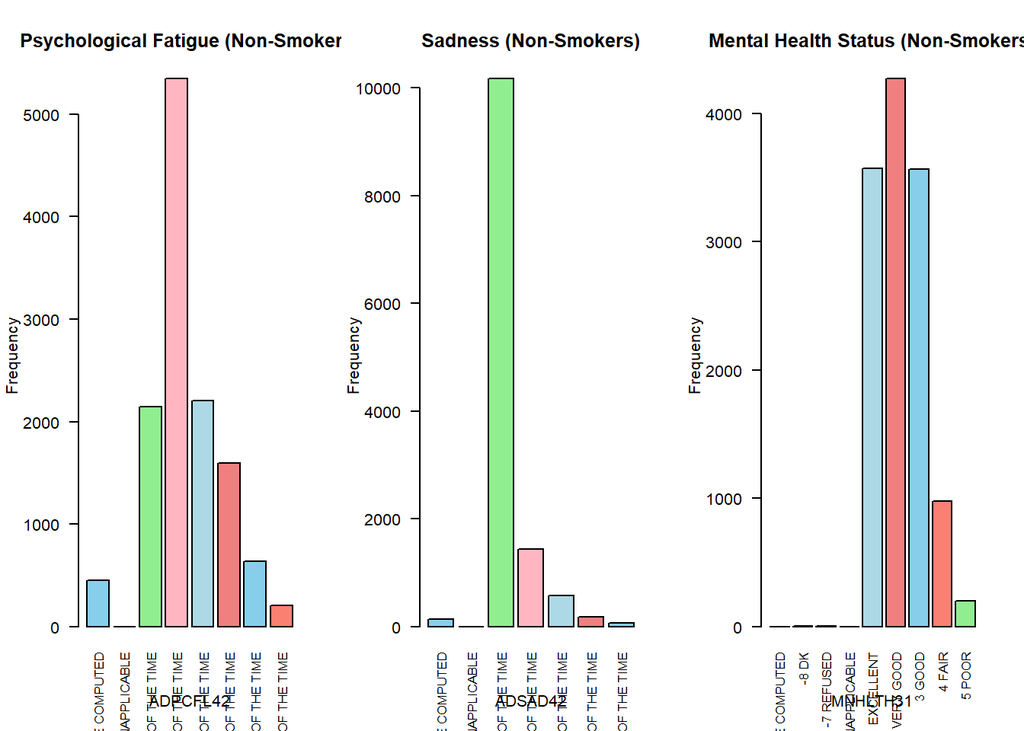

```r
create_plots_mental_health(non_smokers_df, mental_health_variables, titles_non_smokers_mental_health)
```

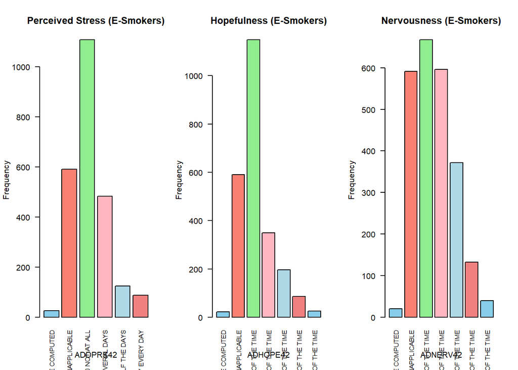

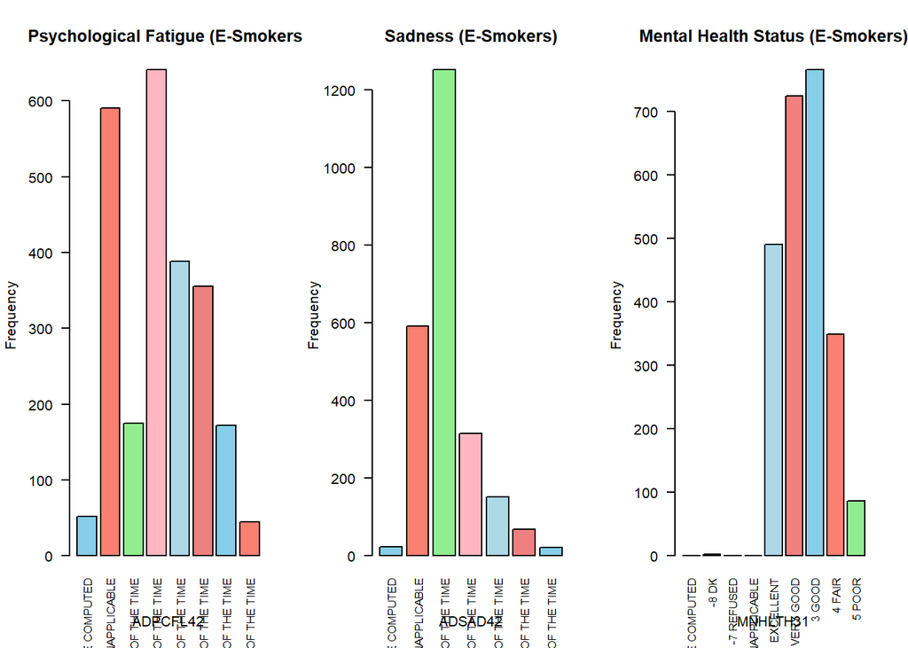

```r
create_plots_mental_health(e_smokers_df, mental_health_variables, titles_e_smokers_mental_health)
```

*Highlights*

## 2.3 General Health Variables

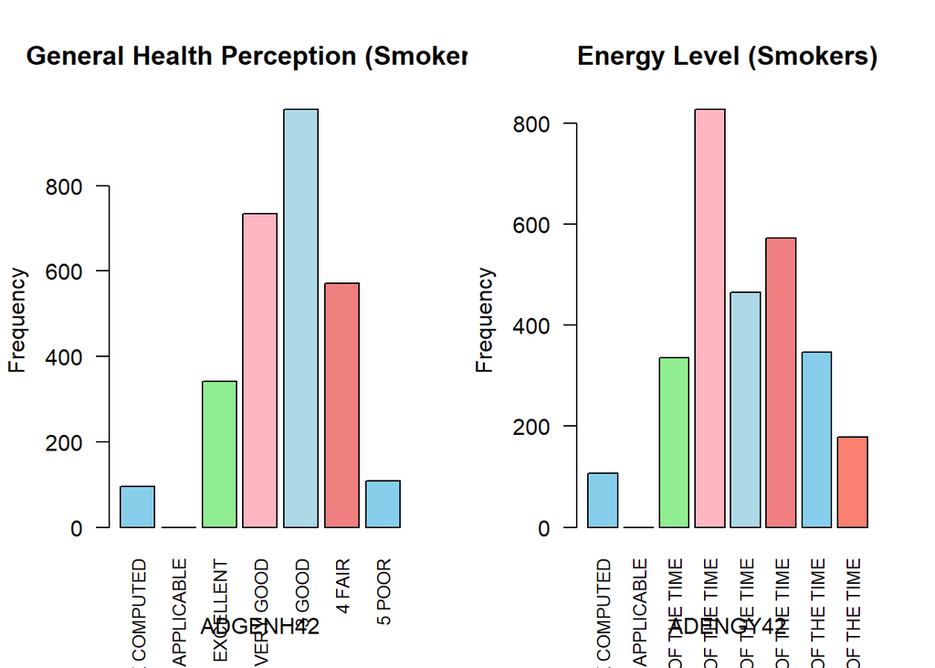

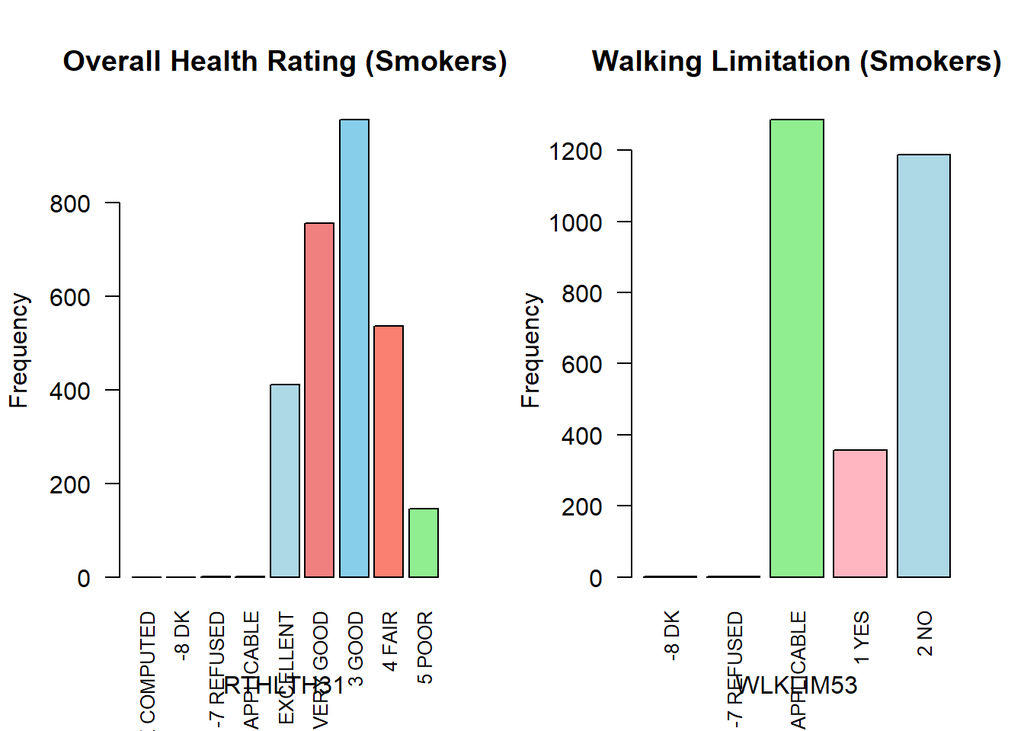

```r
create_plots_general_health <- function(data, general_health_variables, titles) {
  data <- data %>%
    filter(!is.na(sex_group))

create_plots <- function(data, variable, title) {
    my_colors <- c("skyblue", "salmon", "lightgreen", "lightpink", "lightblue", "lightcoral")
    barplot(table(data[[variable]]), main = title, xlab = variable, ylab = "Frequency", las = 2, cex.names = 0.8, col = my_colors)
  }

  par(mfrow = c(1, 2))
  for (variable in general_health_variables) {
    create_plots(data, variable, titles[[variable]])
  }
}

general_health_variables <- c("ADGENH42", "ADENGY42", "RTHLTH31", "WLKLIM53")


titles_smokers_general_health <- c(
  ADGENH42 = "General Health Perception (Smokers)",
  ADENGY42 = "Energy Level (Smokers)",
  RTHLTH31 = "Overall Health Rating (Smokers)",
  WLKLIM53 = "Walking Limitation (Smokers)"
)

titles_non_smokers_general_health <- c(
  ADGENH42 = "General Health Perception (Non-Smokers)",
  ADENGY42 = "Energy Level (Non-Smokers)",
  RTHLTH31 = "Overall Health Rating (Non-Smokers)",
  WLKLIM53 = "Walking Limitation (Non-Smokers)"
)

titles_e_smokers_general_health <- c(
  ADGENH42 = "General Health Perception (E-Smokers)",
  ADENGY42 = "Energy Level (E-Smokers)",
  RTHLTH31 = "Overall Health Rating (E-Smokers)",
  WLKLIM53 = "Walking Limitation (E-Smokers)"
)


create_plots_general_health(smokers_df, general_health_variables, titles_smokers_general_health)
```